# Similar topologies of individual‐based plant‐herbivorous networks in forest interior and anthropogenic edges - Carvalho - - Austral Ecology - Wiley Online Library

[figure not shown]

Research Article

Full Access

# Similar topologies of individual‐based plant‐herbivorous networks in forest interior and anthropogenic edges

[Raquel L Carvalho](https://onlinelibrary.wiley.com/action/doSearch?ContribAuthorStored=Carvalho%2C+Raquel+L)

[Diego V Anjos](https://onlinelibrary.wiley.com/action/doSearch?ContribAuthorStored=Anjos%2C+Diego+V)

[Roberth Fagundes](https://onlinelibrary.wiley.com/action/doSearch?ContribAuthorStored=Fagundes%2C+Roberth)

[Pedro Luna](https://onlinelibrary.wiley.com/action/doSearch?ContribAuthorStored=Luna%2C+Pedro)

[Sérvio Pontes Ribeiro](https://onlinelibrary.wiley.com/action/doSearch?ContribAuthorStored=Ribeiro%2C+S%C3%A9rvio+Pontes)

First published: 28 January 2021

https://doi.org/10.1111/aec.13001

## Abstract

Understanding the impacts of edge effects on ecological interactions plays an integral role in planning ecosystem recovery from human perturbations, as well as conservation of habitats. Edge effects related to forest fragmentation cause changes in species diversity that can disrupt ecological networks. Here, we evaluated how the diversity of, and interactions between, herbivorous insects associated with individuals of a pioneer plant species, *Mabea fistulifera* (Euphorbiaceae) are affected by the disturbances related to edge effects. We addressed two specific questions: (i) How do the forest edges affect species richness, abundance and composition of herbivorous interacting with *M. fistulifera*? (ii) Do different disturbances related to edge effects affect the topology of individual‐based plant‐herbivorous networks? Herbivorous insects were sampled from three population patches of *M. fistulifera* in Brazilian Atlantic forest areas: two areas were subjected to distinct intensities of anthropogenic disturbances (firebreak and park access road, considered edges of low‐ and high‐impact, respectively), and one in the forest interior (control). We expected a lower species richness and abundance of herbivorous interacting with plants in forest edges than in the forest interior apart from to differences in the species composition. Therefore, based on these predictions, we expected that the various disturbances related to edge effects may change the topology of individual‐based plant‐herbivorous networks. We observed that species richness and abundance of herbivorous in high‐impact environments decreased in relation to forest interior, as well the species composition differed between these areas. Disturbance jeopardised network specialisation but did not change the topology of individual‐based networks, which presented a modular pattern. Edges affected herbivorous diversity and decreased the interaction overlap as individual‐based networks became highly specialised with increasing disturbance. These results enhance the understanding of edge effects and resilience of plant‐herbivorous interactions in regularly disturbed tropical environments.

## Introduction

Anthropogenic disturbances caused by fragmentation of natural ecosystems are important drivers of habitat modification in the remaining natural ecological communities (Murcia 1995). Species diversity decline and loss of ecosystem functions are among the most important changes (Fahrig 2003; Lourenço *et al*. 2019). For instance, anthropogenic borders of a fragmented forest are subject to the edge effect, which is characterised by presenting different biotic (e.g. species diversity) and mainly abiotic conditions (e.g. temperature, luminosity, wind speed and air humidity) compared to forest interior (Williams‐Linera 1990; Magnago *et al*. 2015). Such modified environmental conditions in forest edges tend to affect species diversity and ecological interactions (De Carvalho et al. 2014, Pinho *et al*. 2017) through differential land use (De Araújo *et al*. 2015; Benítez‐Malvido *et al*. 2016; Alves‐Silva *et al*. 2020) and shifting environmental stressors (López‐Carretero *et al*. 2014). As such, edges favour mostly generalist species such as pioneers and exotics (Harper *et al*. 2005).

In general, plant species adjust their growth form (Yamada et al., 2000), chemical defences (Yamawo *et al*. 2014), nutrient absorption (Chapin, 1983) and other traits under different abiotic conditions such as forest edges. As conditions change from forest to open vegetation, pioneer plant species are favoured mainly due to increased temperature and light availability (Laurance *et al*. 2006; Santos *et al*. 2010). These pioneer plants create a dynamic and quickly variable habitat for arthropod fauna, favouring generalist herbivorous insects, for instance (Valladares *et al*. 2006; Rossetti *et al*. 2017). Herbivorous insects take advantage of the greater tissue nutrient concentration, better palatability of these tissues and the low investment of these plants in defences against herbivory (Coley et al., 1985; Fortin & Mauffette 2001; Ribeiro *et al*. 2008). In addition, these insects have greater oviposition rates in sun‐light leaves (Moore *et al*. 1988). Herbivorous can drive plant diversity in the tropics, affecting the distribution of species through predation and parasitism of seeds and seedlings (Janzen 1970; Bagchi *et al*. 2014). Herbivorous also limit the growth rates of populations, influencing habitat colonisation and even speciation (Fine *et al*. 2004; Ribeiro & Brown 2006). Therefore, herbivory along with pollination, are remarkable plant–animal interactions (Crawley 1983). For conservation, it is crucial to understand how edge disturbances change the properties of interaction networks and how these properties vary over space and time (Valladares *et al*. 2006; Pinho *et al*. 2017).

In the Atlantic forest, the pioneer plant species *Mabea fistulifera* Mart. (Euphorbiaceae) can be found in both the edge and the interior of forest fragments (Campos *et al*. 2006; Ribeiro *et al*. 2008). *Mabea fistulifera* has the capacity to live in open environments and to overcome shade in the forest interior by adjusting its crown architecture to small canopy spaces (Carvalho & Ribeiro 2018). Just as environmental conditions, the presence of latex in *M. fistulifera* may function as a filter for generalist insects, which are unable to deal with large amounts of latex (Dussourd & Eisner 1987; Farrell *et al*. 1991). Our group's previous studies on *M. fistulifera* have recorded few species and low abundance of herbivorous insects per tree, with Curculionidae, Chrysomelidae and Anobiidae being the most dominant herbivorous families (Ribeiro *et al*. 2008). The beetle *Syphraea* spp. (Coleoptera: Chrysomelidae) is a restricted specialist herbivorous of *M. fistulifera* because it can deactivate latex channels by cutting veins (Becerra 1994, Williams, 1991). Therefore, *M. fistulifera* trees in the forest interior are attacked by this restricted fauna of specialist herbivorous that can break its defences and therefore build stable herbivory interactions. However, *M. fistulifera* in the forest edges, besides to exhibiting less structural complexity (e.g. lower height and fewer twigs, leaves and branches) (Carvalho & Ribeiro 2018), may not have the same line of defences as forest interior trees and could be attacked by several different opportunist herbivorous (Wirth *et al*. 2008). This can impact in the plant's fitness and then in forest recovery.

The Complex Networks Theory has been an important tool for understanding how anthropogenic disturbances affect not only species diversity but also their trophic interactions (López‐Carretero *et al*. 2014; Falcão *et al*. 2015; Fagundes *et al*. 2018; Alves‐Silva *et al*. 2020). However, this approach has focused mainly on community‐level interactions (i.e. interspecific interactions) (but see Benítez‐Malvido *et al*. 2014, 2016). For instance, in a global review considering community‐based plant‐herbivorous networks, the land use intensity and network specialisation (the level at which species interact with more species) presented a positive relationship due to the reduction of host plants of herbivorous guilds with highly specialised feeding habits (De Araújo *et al*. 2015). Pinho *et al*. (2017) showed that the edge effect affects negatively the structure and stability of plant‐herbivorous networks. This classic interspecific approach has been used to understand many aspects of community dynamics, ignoring that the individuals of a population can interact with others species in different ways, which influences the structure of their interactions under a network approach (Pires *et al*. 2011; Benítez‐Malvido *et al*. 2014, 2016). In bipartite individual‐based networks, nodes of one trophic level are represented by different individuals of the same population and the other trophic level is represented by the species with which the individuals interact (Pires *et al*. 2011). This approach also can be an important tool in conservation studies, for instance, showing the importance of how a single plant species may offer food and habitat for associated fauna in human‐impacted landscapes (Benítez‐Malvido *et al*. 2014, 2016). As *M. fistulifera* is often used in forest recovery plans, their ecological interactions with herbivorous (e.g. individual‐based networks) under different disturbances related to edge effects can tell us about their true role in forest recovery and in habitat conservation. For instance, individual‐based plant‐herbivorous networks which exhibit a nested pattern of interactions, due to specialist species (e.g. *Syphraea* spp.) that tend to interact with a core subset of *M. fistulifera* individuals which presents specific interactions with other herbivorous, can increase the plant growth and/or their fitness in disturbed environments where these specialist species are absent or less abundant (Wimp *et al*. 2011; Rossetti *et al*. 2017).

Our study aimed to assess whether different disturbances related to edge effects (firebreak and park access road, considered low‐ and high‐impact, respectively) affect the diversity of herbivorous insects associated with individuals of a dominant plant species and the consequences of possible changes in diversity in individual‐based plant‐herbivorous networks. Our study addresses two specific questions: (i) How do the forest edges affect species richness, abundance and composition of herbivorous interacting with *M. fistulifera*? (ii) Do different disturbances related to edge effects change the topology of individual plant‐herbivorous networks? We expected a lower species richness and abundance of herbivorous interacting with plants in forest edges than in the forest interior (Rossetti *et al*. 2017), reducing frequency of interactions in forest edges. We also predicted differences in the species composition, with trees in the edges presenting a subset of the herbivorous species associated with trees in the forest interior (Benítez‐Malvido *et al*. 2014, 2016), and a lack of specialist herbivorous in favour of generalist herbivorous (Tscharntke *et al*. 2002; Wirth *et al*. 2008; Rossetti *et al*. 2017). Finally, based on these predictions, we expected that the various disturbances related to edge effects may change the topology of individual‐based plant‐herbivorous networks. Moreover, if diversity of specialist herbivorous is lower with increasing disturbances, the interactions might display lower niche breadth and overlap (i.e. lower nestedness, higher specialisation and higher modularity).

## Materials and Methods

### Study area

We worked in the Atlantic forest of south‐eastern Brazil, one of the most fragmented and disturbed ecosystems in the world (Ribeiro *et al*. 2009). The study site is located in Parque Estadual do Rio Doce (hereafter, PERD; 19º30' ‐ 19º48'S, 42º30 ‐ 42º36'W), in the state of Minas Gerais. The park covers 35 973 ha and is the last large remnant of Atlantic forest in Minas Gerais. The elevation ranges in from 200 m to 500 m a. s. l. Most of the vegetation at PERD consists of the domain of the Atlantic semideciduous forest (Lourenço *et al*. 2019). The regional climate is warm and humid, with temperatures fluctuating between 28ºC and 39ºC in the wet season, and between 7ºC and 20ºC in the dry season. Annual precipitation varies between 1350 mm and 1900 mm (De Paula et al. 2002).

### Plant species

We studied *Mabea fistulifera* Mart. (Euphorbiaceae), a dominant pioneer species in the region and an essential species in natural succession. *Mabea fistulifera* is classified as medium‐sized, semideciduous, heliophytic and arboreal. It is found in low open forest and disturbed forests (Carvalho & Ribeiro 2018) and is an essential component of the park's low and open forest canopies. This species has bat pollination syndrome, thus large pollen dispersion, capable of connecting patches, typically found in disturbed spots or forest edges in a forest ecosystem (Goulart *et al*. 2005). As a consequence, there is substantial genetic variability inside population patches, but little variability between‐population patches inside a forest (Goulart *et al*. 2005). Flowering occurs from January to May with peak flowering occurring at the beginning of the dry season in April and May. Extrafloral nectaries and domatia are absent in *M. fistulifera*; its trunk, branches and leaves accumulate a large amount of latex (Lorenzi 1992). When occurring in edges of forest fragments, this species tends to predominate in the tree line, on the actual edge between the forest and the disturbed/modified landscape. This study system is part of the Rio Doce Long‐term ecological research, and the *M. fistulifera* populations have been under investigation since 1999 (Goulart *et al*. 2005; Campos *et al*. 2006; Ribeiro *et al*. 2008).

### Sample design

We focused on low forest habitat (10–20 m tree height) in the southern part of the PERD. This focus on a single forest type eliminated the effect of additional habitats, such as those created by the presence of emergent trees. We sampled the insect herbivorous fauna on individuals of three *M. fistulifera* populations patches in environments with different disturbance levels. As ecological control (i.e. a population subject only to sporadic natural disturbances), we took samples from one *M. fistulifera* population in a forest interior area (hereafter 'forest interior') at least 350 metres from the natural edge, in which there are no recorded *M. fistulifera* individuals. Forest interior can be referred to as late secondary forest and is composed of a mix of persistent and pioneer tree species (mainly *M. fistulifera*) with a preserved and well‐developed canopy. *Mabea fistulifera* in the forest interior has an upper canopy about 15 m, on average.

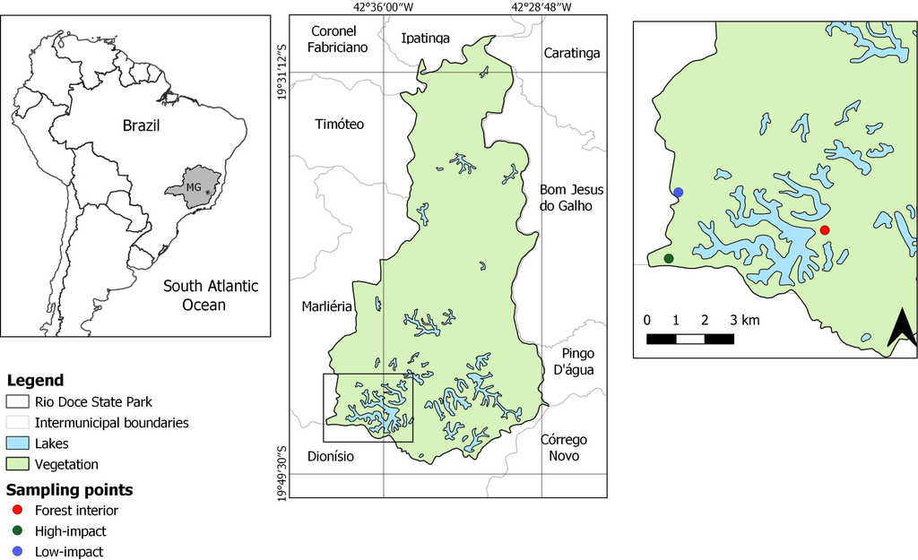

**Fig. 1**

Population patches of *Mabea fistulifera* (Euphorbiaceae) in Parque Estadual do Rio Doce, Minas Gerais, Brazil.

The forest edges we investigated are dominated by *M. fistulifera*. We sampled the trees in the forest edges up to five metres away from the edge (Fontoura *et al*. 2006). Given that *M. fistulifera* presents greater within‐population genetic variability than between‐population variability (Goulart *et al*. 2005), we concentrated our sampling effort on the number of individuals within each population/environment. Despite the individual's height shows considerable variation among environments ‐ within each environment, we sampled 15 trees of similar height and at least 20 m apart (*N* = 45 individuals of *M. fistulifera*). We choose adult plants because the leaves of adults accumulate large amounts of latex and the herbivorous fauna at this stage is similar and persistent for long periods (SP Ribeiro *personal observation)*.

### Herbivorous insect sampling

We sampled nine trees (three in each environment) per day. Each day, new trees were sampled, totalising five consecutive days (total of 5 days × 9 trees per day per environment = 45 independent trees), per sampling event. We used a standardised sampling order of the trees and sites. These individuals were tagged and sampled during the study period. This same sampling effort was made in the wet and dry seasons for two consecutive years, totalising four sampling events. Specifically, we sampled all individuals on sunny days in February (wet season) and July (dry season) of 2011 and 2012. We sampled insects, between 9:00 am and 3:30 pm each day; this corresponded with the period of greatest insect activity (Neves *et al*. 2013). Despite sampling at different stations, individuals had similar phenological conditions during sampling events (Goulart *et al*. 2005). Insects in the crowns of *M. fistulifera* were sampled by beating (Ribeiro *et al*. 2005). An adapted entomological umbrella was put under three branches of each randomly chosen tree, and each branch was hit ten times to remove the fauna (see Ribeiro *et al*. 2005). To access the tree crowns in the canopy, we used single‐rope and safety‐free climbing techniques (Ribeiro & Basset 2007; Neves *et al*. 2013). This technique has been shown to be a good proxy to measure antagonistic interactions such as herbivory (Wardhaugh *et al*. 2015; Augustyn *et al*. 2016; Oliveira *et al*. 2019).

Samples were frozen and transported to the laboratory for processing, identification and enumeration. Coleoptera and Hemiptera individuals were identified to the lowest taxonomic level using keys in Borror *et al*. (2002), and to species level, when possible, by comparison with named species in the 'Laboratório de Ecologia Evolutiva de Insetos de Dossel e Sucessão Natural' of Federal University of Ouro Preto. Collection vouchers were also deposited at the Federal University of Ouro Preto. We only included species as herbivorous insects after checking their mouthparts and feeding habits (Borror *et al*. 2002). Species that could not be confidently named were assigned morphospecies number codes that apply only to this study. We choose Coleoptera and Hemiptera insects because they are the main group of chewing herbivorous and sucking herbivorous, respectively (Borror *et al*. 2002). In addition, the number of immature Lepidoptera was irrelevant, and the few individuals falling down in the entomologic umbrella were normally too damaged to allow identification at any sort. Furthermore, previous work from our group on insect herbivorous on this *M. fistulifera* population already showed little relevance of Lepidoptera group on the insect herbivorous assembly (Ribeiro *et al*. 2008).

### Data analysis

As the data set was small in each sampling event, we decided to group them (four sampling events) and apply a more complete approach towards our goal. We considered each tree as a sample (*n* = 15 for each area) and measured herbivorous richness (number of species) and abundance (number of individuals) as dependent variables of each sample. As explanatory variables, we used the type of environment: forest edges (low and high‐impact edges) and forest interior (control). To evaluate differences in herbivorous richness and abundance between populations of all three environments, we used generalised linear models (GLMs) with quasi‐Poison error distribution. When models indicated differences in explanatory variables, we made *post hoc* comparisons with the multcomp package (Bretz *et al*. 2010). We checked the adequacy of each model by examining the distribution of residuals (Crawley 2012). We used the relative abundance of herbivorous species per tree to calculate the similarity between the trees of all three environments (Bray–Curtis Index). We used ANOSIM models followed by a Bonferroni paired test to evaluate differences in composition of herbivorous species interacting with *M. fistulifera* individuals of all three environments. Based on the same similarity matrix, we built an ordering graph using the NMDS model to represent the difference between trees of all three environments. We conducted GLMs and *post hoc* analysis in R 3.5.3 platform (R Core Team 2019) using the interface Action 3.2 (Statcamp), and ANOSIM and NMDS in the software PAST 3.16 (Hammer *et al*. 2001).

To evaluate the edge effects on the interactions among individual plants and their herbivorous insects, we used a network analysis using tools derived from the Complex Networks Theory (Jordano *et al*. 2003; Blüthgen *et al*. 2006; Almeida‐Neto *et al*. 2008). To search for differences in plant‐herbivorous network topology, we constructed incidence matrices, where a<sub>ij</sub> = number of interactions an individual tree *i* with herbivorous insect *j*, and *0* where there are none. We considered the number of interactions as abundance of herbivorous insects (number of individuals) in each sampling event accumulated over time. We constructed three matrices: i) the interactions in the forest interior, ii) the interactions in the low‐impact edge and iii) the interactions in the high‐impact edge. Each matrix represents the interaction of 15 trees with their herbivorous, enabling analysis of the variation of interactions among a subset of the individuals of a certain population. From these matrices, we calculated network size by multiplying the number of individuals by the number of herbivorous in the network, which gives us an estimate of the number of possible interactions. We also calculated the degree (number of interactions) of the networks; the number of interactions that each tree shared with herbivorous morphospecies (shared partners), as a measure of herbivorous' interaction niche width (Jordano *et al*. 2003). To measure the overlap and niche breath at a network level, we used the complementary specialisation of the interactions ( Index) (Blüthgen *et al*. 2006). This index measures the specialisation of a network assuming that rare interactions do not reflect real specialisation, and it ranges from 0 (completely generalist network, complete overlap of interactions) to 1 (completely specialised network, no overlap of interactions). We evaluated the significance of the index (i.e. if the observed index value differs from a value obtained by a null model) for each of the studied sites: interior forest, low and high‐impact edge. To achieve this, we simulated 1000 null networks of each the studied sites (1000 iterations per network), using the Patefield algorithm (Patefield 1981). With the simulated null networks we estimated 1000 values, and then we compared if the observed value of differed from the ones obtained by the null model.

To further explore if there were differences between the studied networks, we tested whether the absolute difference in the observed values of was higher than would be expected in simulated networks generated by a null model using Patefield algorithm (Patefield 1981). Using this approach, we first estimated the values of two observed networks; then we estimated the difference between both values. Further, to assess if the observed differences in the values of are not a results of randomness, we simulated 1000 null networks of each of the networks to be compared (1000 iterations per network), we then estimated the index for the iterated networks and estimated its differences (by subtraction) to obtain 1000 values of the expected differences between the two focal networks. In the end we compared if the observed difference of the index differs from the differences obtained by iterating the differences with null models. We compared the observed and simulated differences in values between i) forest interior and the low‐impact edge networks, ii) forest interior and the high‐impact edge networks, and iii) low‐impact and high‐impact networks; 1000 interactions were simulated for each of the three comparisons (i, ii and iii). Furthermore, to search for non‐random patterns of interactions (i.e. topology) between a subset of herbivorous species and plant individuals, we calculated the level of nestedness (redundancy of interactions) using the WNODF‐metric method (Weighted Nestedness Metric Based on Overlap and Decreasing Fill) (Almeida‐Neto & Ulrich 2011). The nestedness values range from 0 (non‐nested) to 100 (perfectly nested). We estimated the degree of modularity (segregation of interactions) using the QuanBiMo (Q) algorithm (Dormann & Strauss 2014). This algorithm calculates the modularity for weighted networks using the Likelihood and Simulated Annealing‐Monte Carlo approach (Dormann & Strauss 2014). The modularity index (Q) ranges from 0 (no subgroups) to 1 (totally separate subgroups). Here, modules represent groups of individual plants in the populations that shared higher number of interactions of similar herbivorous species. To test whether the computed values actually reflect a non‐random structure, we applied a null model approach in which we generated 1000 random matrices, using the Patefield algorithm (Patefield 1981); we compare if the observed value differed from the ones obtained by the null model. Further, the computed values of nestedness and modularity were standardised using *Z*‐scores to control the differences in richness, connectance and heterogeneity among networks (e.g. network size). The *Z*‐transformed score is defined: *Z* = [*x* ‐ *µ*]/*σ*, where *x* is the observed index value, *µ* is the mean of the values from simulated matrices, and *σ* is the standard deviation of the values from simulated matrices (Almeida‐Neto *et al*. 2008). We estimated the significance of the network descriptors using *Z*‐scores (values ≥ 2) (Dormann & Strauss 2014). The value of the *Z*‐score shows the magnitude of the difference between the null model and the observed network descriptor, whereby a *Z*‐score of 7 (e.g. for modularity) means that the observed modularity is 7 standard deviations higher than would be expected from random networks. *Z*‐scores above 2 are considered significantly modular (2 standard deviations). Negative *Z*‐score values can arise if the mean of the null models is higher than the observed value, if the value is positive it indicates that the mean of the null models is lower than the observed value. Finally, to describe herbivorous species as peripheral (selective species, which have few interactions) or generalist core (‘generalist’ species, which have the most interactions) components of the networks, we used the formula proposed by Dáttilo *et al*. (2013): Gc = (ki − kmean)/σk, where ki = mean number of links for a given species, kmean = mean number of links for all species in the network, and σk = standard deviation of the number of links for each species. Gc > 1 are herbivorous species of the ‘generalist’ core, and Gc < 1 are peripheral herbivorous species. The index, WNODF, Q algorithms, the null models and core‐periphery formula were calculated with the ‘bipartite’ package (Dormann *et al*. 2017) available in R 3.5.3 platform (R Core Team 2020). We built the interaction network graphs for each environment in ‘igraph’ package (Csardi & Nepusz 2006).

## Results

We found 394 herbivorous from 78 morphospecies in 45 trees of *M. fistulifera* (9 ± 8.68, mean ± SD of individuals per tree). This total comprised 358 coleopteran chewers from 62 morphospecies in 41 trees, and 36 hemipteran sap‐suckers from 16 morphospecies in 18 trees (Table 1). A total of 206 of these herbivorous (52%), representing 49 morphospecies, occurred in trees within the forest interior, 134 (34%) herbivorous from 32 morphospecies occurred in trees of low‐impact edge and 54 (14%) herbivorous from 28 morphospecies occurred in trees of high‐impact edge. On average, there were differences in abundance (*F*<sub>2,42</sub> = 5.86, *P* < 0.01) and richness (*F*<sub>2,42</sub> = 7.61, *P* < 0.01) of herbivorous insects between the three environments. The trees in forest interior only had more individuals (*F*<sub>2,42</sub> = 5.7, *P* < 0.01) and more species of herbivorous (*F*<sub>2,42</sub> = 5.3, *P* < 0.01) than trees in high‐impact edge (Tukey: *P* < 0.01, Fig. 2a, b). No difference was found between the abundance and richness of herbivorous between trees in the forest interior and low‐impact edges, neither between the anthropogenic edges (Tukey: *P* > 0.05).

Table 1. List of coleopteran and hemipteran species in *Mabea fistulifera* trees and their abundances in the three disturbance levels in Atlantic Forest of Rio Doce basin (Brazil)

| Morphospecies | Code | Forest interior | Low‐impact edge | High‐impact edge |
| --- | --- | --- | --- | --- |
| Coleoptera |  |  |  |  |
| Byrrhidae sp 1 | BL1 | 01 | – | 01 |
| Byrrhidae sp 2 | BL2 | – | 02 | – |
| Byrrhidae sp 3 | BL3 | – | 01 | – |
| Byrrhidae sp 4 | BL4 | – | 01 | – |
| Byrrhidae sp 5 | BL5 | 01 | 01 | 01 |
| Byturidae sp 1 | BT1 | – | 01 | 01 |
| Byturidae sp2 | BT2 | – | – | – |
| Buprestidae sp 1 | BU2 | 01 | – | – |
| Chelonariidae sp 3 | CH3 | – | – | 01 |
| Chrysomelidae alticinae parasyphraea sp 1 | CAP1 | 12 | 05 | 05 |
| Chrysomelidae alticinae syphraea sp 1 | CAS1 | 33 | 37 | 08 |
| Chrysomelidae alticinae syphraea sp 2 | CAS2 | 98 | 39 | 05 |
| Chrysomelidae alticinae syphraea sp 3 | CAS3 | 02 | 01 | – |
| Chrysomelidae alticinae sp 6 | AL6 | 01 | – | – |
| Chrysomelidae alticinae sp 7 | AL7 | 01 | – | – |
| Chrysomelidae alticinae sp 8 | AL8 | 01 | – | – |
| Chrysomelidae alticinae sp 56 | AL56 | 01 | 01 | – |
| Chrysomelidae alticinae sp 57 | AL57 | 02 | 02 | 01 |
| Chrysomelidae alticinae sp 58 | AL58 | – | 10 | – |
| Chrysomelidae bruchinae sp 1 | BR1 | 01 | – | – |
| Chrysomelidae cassidinae sp 1 | CA1 | – | – | 01 |
| Chrysomelidae cassidinae sp 2 | CA2 | 01 | 01 | – |
| Chrysomelidae cryptocephalinae sp 4 | CC4 | – | 01 | – |
| Chrysomelidae cryptocephalinae sp 5 | CC5 | 01 | – | – |
| Chrysomelidae cryptocephalinae sp 13 | CC13 | 01 | 01 | – |
| Chrysomelidae crysomelinae sp 1 | CC1 | – | – | – |
| Chrysomelidae eumolpinae sp 4 | CEC4 | 01 | – | – |
| Chrysomelidae eumolpinae sp 13 | CE13 | – | – | 01 |
| Chrysomelidae eumolpinae sp 14 | CE14 | – | – | 01 |
| Crysomelidae galerucinae sp 33 | CG33 | 01 | – | – |
| Cupedidae sp 1 | C1 | 01 | – | – |
| Curculionidae scolytinae sp 3 | US3 | 01 | – | – |
| Curculionidae sp 1 | U1 | 01 | – | 01 |
| Curculionidae sp 2 | U2 | 01 | 01 | – |
| Curculionidae apioninae apion sp 1 | CAA1 | 02 | 06 | 02 |
| Curculionidae apioninae sp 5 | UA5 | – | 01 | – |
| Curculionidae apioninae naupactus sp 3 | CAN3 | 01 | – | – |
| Curculionidae apioninae naupactus sp 4 | CAN4 | 01 | – | – |
| Curculionidae baridinae sp1 | CBM1 | – | 01 | – |
| Curculionidae baridinae sp 7 | UB7 | 01 | – | 02 |
| Curculionidae baridinae sp 8 | UB8 | – | 01 | – |
| Curculionidae baridinae zygobaridina sp1 | UBZ1 | – | – | 01 |
| Curculionidae belinae sp 2 | UB2 | 05 | – | – |
| Curculionidae belinae sp 32 | UB32 | – | 02 | – |
| Curculionidae brachycerinae sp 1 | UB1 | 02 | – | – |
| Curculionidae cryptorhynchinae sp 1 | UC1 | 03 | – | – |
| Curculionidae curculioninae sp 6 | UU6 | – | – | 01 |
| Curculionidae curculioninae sp 11 | UU11 | – | 11 | – |
| Curculionidae curculioninae sp 20 | UU20 | 01 | – | – |
| Curculionidae curculioninae sp 44 | UU44 | 01 | – | – |
| Curculionidae curculioninae sp 46 | UU46 | 01 | – | 01 |
| Curculionidae curculioninae sp 47 | UU47 | 01 | – | – |
| Curculionidae curculioninae sp 51 | UU51 | – | 01 | 01 |
| Curculionidae curculioninae sp 55 | UU55 | 01 | – | – |
| Curculionidae curculioninae sp 56 | UU56 | – | – | 01 |
| Curculionidae curculioninae sp 57 | UU57 | 01 | – | – |
| Curculionidae curculioninae sp 58 | UU58 | 01 | 01 | – |
| Curculionidae curculioninae sp 64 | UU64 | 02 | – | – |
| Curculionidae curculioninae sp 65 | UU65 | 01 | – | 01 |
| Curculionidae molytinae sp 4 | UM4 | 01 | – | – |
| Curculionidae molytinae sp 5 | UM5 | 02 | 01 | – |
| Phalacridae sp 4 | P4 | 01 | – | – |
| Hemiptera |  |  |  |  |
| Cicadellidae sp1 | CI1 | – | 01 | – |
| Cicadellidae sp 2 | CI2 | – | 01 | – |
| Cicadellidae sp 5 | CI5 | 01 | 01 | – |
| Cicadellidae sp 22 | CI22 | – | 01 | – |
| Cicadellidae sp 24 | CI24 | 01 | – | – |
| Fulgoridae sp 3 | F3 | 02 | – | 01 |
| Fulgoridae sp 11 | F11 | 03 |  | 02 |
| Lygaeidae sp 6 | L6 | – | 01 | – |
| Membracidae sp 1 | M1 | – | – | 01 |
| Membracidae sp 10 | M10 | – | – | 08 |
| Membracidae sp 13 | M13 | 02 | – | 02 |
| Membracidae sp 15 | M15 | – | 01 | – |
| Miridae sp 2 | MI2 | 01 | – | – |
| Nabidae sp 1 | N1 | 02 | – | 01 |
| Pyrrhocoridae sp 1 | PY1 | – | – | 01 |
| Tingidae sp 1 | T1 | 01 | – | 01 |

- –, Represents the absence of individuals in the trees.

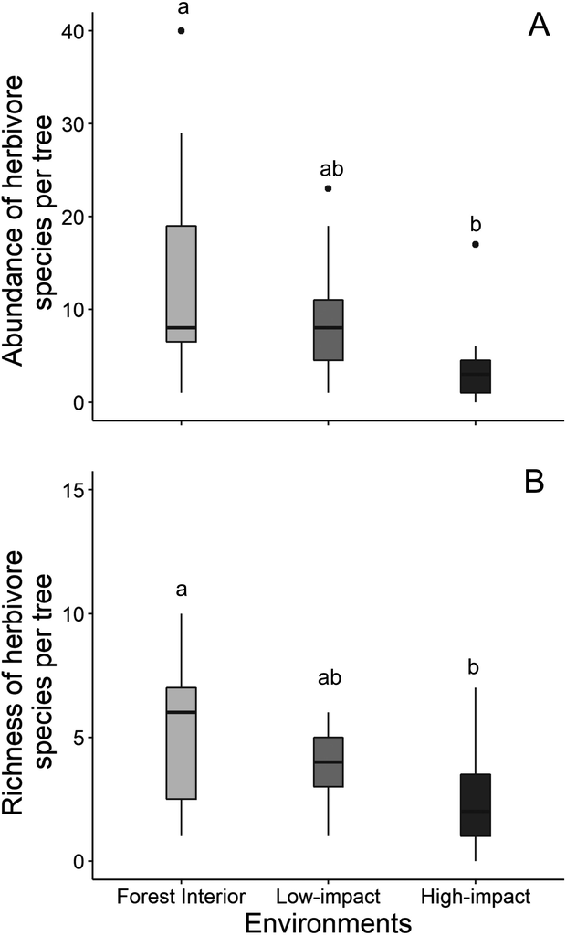

**Fig. 2**

Analysis of response of the diversity of herbivorous interacting with *Mabea fistulifera* trees in three Atlantic Forest environments in the Rio Doce basin (Brazil). Comparison of the average number of herbivorous individuals (a) and morphospecies (b) per tree (*N* = 15).

The species composition of herbivorous populations that interacted with *M. fistulifera* differs depending on the environment (ANOSIM: *R*<sup>2</sup> = 0.28, *P* < 0.01). Our results showed a similarity gradient in the herbivorous species composition, ranging from trees in the high‐impact edge to trees in both the forest interior and low‐impact edge, which form two indistinct interaction systems. Still, such differentiation happened only along axis 1 of the NMDS matrix, which explained 24% of data variation (Stress = 0.11) (Fig. 3). Trees of the high‐impact edge had 11 exclusive herbivorous morphospecies, while the trees of the low‐impact edge had 18 exclusive, and trees of the forest interior had 25 exclusive herbivorous.

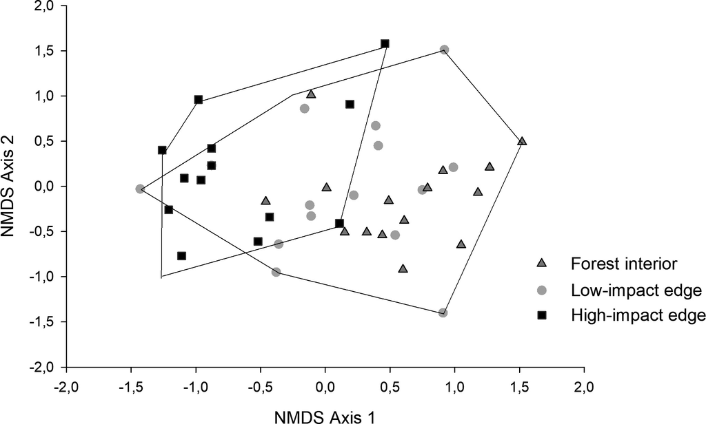

**Fig. 3**

NMDS showing variation in herbivorous insect morphospecies composition in *Mabea fistulifera* trees using a similarity matrix constructed from Bray–Curtis index in three Atlantic Forest environments in Rio Doce basin (Brazil). Polygons represent a difference in herbivorous species composition between the high‐impact edge and both forest interior and low‐impact edge. Forest interior (triangles); low‐impact edge (circles) and high‐impact edge (squares). Stress = 0.11.

The size and number of interactions of the network were higher in the forest interior (64 components, 84 interactions) when compared to the low‐impact (47, 56) and high‐impact edges (43, 37). Herbivorous morphospecies shared more plants in the forest interior (0.25 shared plants/herbivorous morphospecies) than in low‐impact (0.18) and high‐impact (0.14) edges, creating a gradient in specialisation interactions from a more generalised network in forest interior (observed = 0.26, null‐value = 0.11 ± 0.02) to a more specialised network in low‐impact (observed = 0.49; null‐value = 0.14 ± 0.03) and high‐impact edges (observed = 0.60, null‐value = 0.18 ± 0.06). However, the observed differences in values did not differ between the low‐ and high‐impact networks when compared to the randomised differences of values. Whereas, the low‐ and high‐impact networks had a greater complementary specialisation when compared to the interior network (Table 2).

Table 2. Comparison between the observed differences in the values of the low‐impact, high‐impact and interior networks

| Networks compared | differences | *P*‐value |
| --- | --- | --- |
| High v.s. Low | 0.1 | 0.15 |
| High v.s. Interior | 0.33 | 0.001 |
| Low v.s. Interior | 0.23 | 0.001 |

- The *P*‐values where calculated by comparing the observed differences with simulated differences of 1000 random networks.

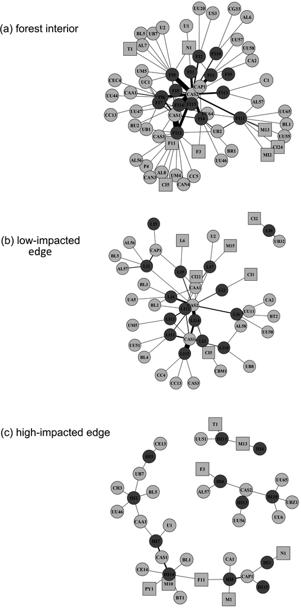

**Fig. 4**

Number of interactions (black lines) between trees of *Mabea fistulifera* (dark grey circles) and its coleopteran (light grey circles) and hemipteran herbivorous (light grey squares). The width of the line represents the relative frequency of interactions based on the percentage of occurrences of a given herbivorous on each tree. The networks exist in either a forest interior (a), a low‐impact edge (b) or a high‐impact edge (c) of an Atlantic Forest area in the Rio Doce basin (Brazil). Acronyms represent the morphospecies of herbivorous, and the description is in Table 1.

Based on the network approach, we found weak differences in the topology of plant‐herbivorous networks in the forest interior and the forest edges. The interactions observed in the forest interior were not nested (WNODF = 10.32, *Z*‐score = 0.40, *P* = 0.30), but they presented a modular network structure (Q = 0.38, *Z*‐score = 7.88, *P* < 0.01). The plant‐herbivorous network in the low‐impact edge also resulted in a non‐nested (WNODF = 7.96, *Z*‐score = −3.83, *P* < 0.01) and modular network (Q = 0.55, *Z*‐score = 12.46, *P* < 0.01). In the high‐impact edge the network topology was similar to the previous ones: non‐nested (WNODF = 2.25, *Z*‐score = −2.7, p < 0.01) and modular network (Q = 0.7, *Z*‐score = 6.7, *P* < 0.01).

## Discussion

We found that *M. fistulifera* individuals in forest interior maintain an abundant and broadly diverse herbivorous fauna, dominated mainly by the specialist herbivorous (e.g. *Syphraea* spp., Chrysomelidae), which can tolerate the plant's latex defence (Becerra 1994; Williams, 1991). Two factors that may contribute to the higher diversity of herbivorous interactions (mainly considering specialist herbivorous) in the forest interior are the higher stability of abiotic conditions and the greater diversity of microhabitats due to plant traits (Ries *et al*. 2004; Campos *et al*. 2006; Ribeiro *et al*. 2008). For instance, *M. fistulifera* individuals in the forest interior can offer large amounts of resources (e.g. number of leaves, twigs and branches) to herbivorous insect fauna. Forest interior *M. fistulifera* can provide enemy‐free spaces (e.g. ants) for breeding and feeding (Ribeiro *et al*. 2005; Ribeiro & Borges 2010) because individuals of *M. fistulifera* are in average four metres taller than those in the edges and present almost twice the amount of leaves (higher complexity) than those in the low‐impact edges (Carvalho & Ribeiro 2018). We cannot disregard that differences in the microclimate produced by the edge effect can change the nutritive and defensive characteristics of some plants. Some forest edge plants may have less direct defences such as leaf toughness, chemical defences and trichomes (Yamawo *et al*. 2014) and greater nutritional quality of tissues (Angold, 1997). These changes may have favoured more generalist species such as *Membracidae* sp. 10 (Wood 1993), which was only sampled in high‐impact edges. Implications of these possible changes (e.g. nutritional content and defence against herbivory) in the topology of individual‐based plant‐herbivorous network need to be investigated.

Although the abundance of herbivorous insects is an important factor for network structure, null models help to prevent this factor from interfering with network metrics. In addition, changes in the abundance of herbivorous insects are also a natural consequence of anthropogenic disturbances (Valladares *et al*. 2006; De Carvalho et al. 2014). We found that the plant‐herbivorous networks in low‐ and high‐impact edges were smaller (network size), interaction frequency was lower, specialisation was higher, and the network topology was modular.

Although the trend is that small networks exhibit a nonmodular pattern (Olesen *et al*. 2007), modularity is expected to increase with interactions specificity, such as plant‐herbivorous networks (Prado and Lewinsohn, 2004; Cagnolo *et al*. 2011; Robinson & Strauss 2020). Here, we have shown that the modular pattern also appears in individual‐based networks. This modular pattern may show that the loss of some herbivorous (e.g. through anthropogenic disturbance) can favour their respective host individuals without causing any major consequences for the network as a whole. Our findings contradict those for community‐level plant‐herbivorous networks (i.e. based on plant species instead of individuals), whose specialisation (at species level) and modularity are lower in high‐stress conditions (e.g. anthropogenic edges) than in forest interior (Pinho *et al*. 2017). However, Robinson and Strauss (2020) used plant‐herbivorous networks under stressful conditions to show that the modular pattern of the network is maintained. Regarding individual‐based networks that do not consider only herbivorous (*Heliconia*‐invertebrates network), the network metrics also are maintained in anthropogenic habitats independent of location and plant species (Benítez‐Malvido *et al*. 2014). The similarity in the structure of the networks also indicates that, despite the disturbances, the network structure remains similar, reflecting resilience to extinctions or perturbations (Olesen *et al*. 2007). Moreover, the maintenance of the pattern found suggests that even in impacted environments, which presents lose some herbivorous species, the most part of herbivory is maintained due to the modular structure, for instance. However, if this herbivorous loss increases and persists over time, the decrease in herbivory pressure can lead to higher growth rates and plant persistence, delaying the natural succession.

Importantly, the variation in traits between individuals is subtler than the variation between species (Tur *et al*. 2014). Edge effects lead to impressive changes in the development and architecture of *Heliconia* individuals in Mexican tropical forest (Benítez‐Malvido *et al*. 2014, 2016) as well as in *M. fistulifera* individuals (e.g. more vertical growth, shorter stems without branches) (Carvalho & Ribeiro 2018). These broad individual variations probably generate specific interactions between individuals and their herbivorous insects. Some herbivorous become more selective or limited to specific groups of individuals, probably those with better resources and lower foraging cost (Boaventura *et al*. 2018; Carvalho & Ribeiro 2018). For instance, *Syphraea* spp. (e.g. CAS2) in forest interior were present in 14 of the 15 trees sampled, but they occupied only three out of 15 trees in the high‐impact edge. Therefore, the greater specialisation in low‐ and high‐impact edges may reflect: (1) individual trait variability (e.g. plant height, number of branches, crown architecture, host individual genotype) among conspecific trees provides greater potential for growth in variable and inconstant environments (Keith *et al*. 2017; Carvalho & Ribeiro 2018), or even plant ontogeny, with plants of different ages growing in the edge, while long‐established adult plants dominate the forest interior (SP Ribeiro *pers*. *obs*.); and (2) lower abundance of the dominant specialist herbivorous can act as interaction hubs connecting all plants in the network (Tabeni & Ojeda 2003).

Despite the absence of individual trait measurements in the high‐impact edge, Carvalho and Ribeiro (2018) found morphological and allometric differences in *M. fistulifera* individuals of the interior forest and low‐impact edge. Population patches of *M. fistulifera* in different areas (e.g. natural and anthropogenic environments) have been studied for over 18 years in the PERD (Ribeiro *et al*., unpublished data). In general, it is expected that the greater the disturbance in the edge, the greater morphological heterogeneity (e.g. number of branches) within the population of *M. fistulifera* (Carvalho & Ribeiro 2018). For instance, the constant disturbance in edges creates gaps in the canopy, favouring the growth and emergence of new individuals (Ribeiro *et al*. 2008). This fact may have created specific interactions between certain herbivorous insect species and certain *M. fistulifera* individuals within developmental or size classes (Cornelissen *et al*. 2008).

In conclusion, our study provides evidence that forest fragmentation and edges affect the diversity of herbivorous insects, but preserve the way these insects interact with pioneer tree species in the Brazilian Atlantic forest. Our results for the ecological networks between *M. fistulifera* and its herbivorous insects showed that specialist herbivorous, which dominate the interactions within the population in preserved forest environments, had a lower frequency in forest edges, but the topology of these networks were maintained. Instead of a highly connected network where herbivorous can eat and control plant growth, forest edges hold highly specialised, poorly connected networks where populations of a few facultative herbivorous are limited to specific trees in a clumped distribution. The oversimplification of the network, through reduced diversity, can destabilise the interaction outcomes and enable pioneer species to prevail over new ones, slowing down natural succession in the edge and the forest traits restoration as a whole.

## Acknowledgements

We thank Dr. Wesley Dáttilo for his advice regarding network comparisons. We thank the Parque Estadual do Rio Doce and IEF for giving us sampling permits. SPR was awarded by CAPES, CNPq and FAPEMIG grants during this research.

## Author Contribution

**Raquel L Carvalho:** Conceptualization (lead); Data curation (lead); Formal analysis (lead); Methodology (lead); Writing‐original draft (lead); Writing‐review & editing (lead). **Diego V Anjos:** Formal analysis (lead); Methodology (lead); Writing‐original draft (lead); Writing‐review & editing (lead). **Roberth Fagundes:** Formal analysis (equal); Methodology (equal); Writing‐original draft (equal); Writing‐review & editing (equal). **Pedro Luna:** Formal analysis (equal); Methodology (equal); Writing‐review & editing (equal). **Sérvio Pontes Ribeiro:** Conceptualization (equal); Data curation (equal); Methodology (equal); Supervision (equal); Writing‐original draft (equal); Writing‐review & editing (equal).

## Conflict of interest

The authors declare no conflict of interest.

## References

[figure not shown]

Online Version of Record before inclusion in an issue

### Details

- © 2021 Ecological Society of Australia

### Research funding

  - Fundação de Amparo à Pesquisa do Estado de Minas Gerais
  - Conselho Nacional de Desenvolvimento Científico e Tecnológico
  - Coordenação de Aperfeiçoamento de Pessoal de Nível Superior

### Keywords

  - antagonisms
  - canopy
  - disturbance
  - [forest fragmentation](https://onlinelibrary.wiley.com/action/doSearch?field1=Keyword&text1=forest%20fragmentation)
  - herbivory

### Publication History

  - Version of Record online: 28 January 2021
  - Manuscript accepted: 16 December 2020
  - Manuscript revised: 13 December 2020
  - Manuscript received: 26 June 2020